# Milestone2

Mikayla Lamping

3/13/2022

# Maternal Risk

## Check for potential data quality issues

```r
maternal_risk <- read_csv("MaternalHealthRiskDataSet.csv")
# No missing values
sum(maternal_risk %>%
  is.na())
```

```
## [1] 0
```

Variable definitions from Kaggle:

- Age: Age in years when a woman is pregnant.
- SystolicBP: Upper value of Blood Pressure in mmHg, another significant attribute during pregnancy.
- DiastolicBP: Lower value of Blood Pressure in mmHg, another significant attribute during pregnancy.
- BS: Blood glucose levels is in terms of a molar concentration, mmol/L.
- HeartRate: A normal resting heart rate in beats per minute.
- Risk Level: Predicted Risk Intensity Level during pregnancy considering the previous attribute.

```r
summary(maternal_risk)
```

```
##       Age          SystolicBP     DiastolicBP           BS
##  Min.   :10.00   Min.   : 70.0   Min.   : 49.00   Min.   : 6.000
##  1st Qu.:19.00   1st Qu.:100.0   1st Qu.: 65.00   1st Qu.: 6.900
##  Median :26.00   Median :120.0   Median : 80.00   Median : 7.500
##  Mean   :29.87   Mean   :113.2   Mean   : 76.46   Mean   : 8.726
##  3rd Qu.:39.00   3rd Qu.:120.0   3rd Qu.: 90.00   3rd Qu.: 8.000
##  Max.   :70.00   Max.   :160.0   Max.   :100.00   Max.   :19.000
##     BodyTemp        HeartRate     RiskLevel
##  Min.   : 98.00   Min.   : 7.0   Length:1014
##  1st Qu.: 98.00   1st Qu.:70.0   Class :character
##  Median : 98.00   Median :76.0   Mode  :character
##  Mean   : 98.67   Mean   :74.3
##  3rd Qu.: 98.00   3rd Qu.:80.0
##  Max.   :103.00   Max.   :90.0
```

HeartRate seems to have at least one outlier, as the minimum is only 7 but the majority of the points are in the 70-80 bpm range.

### Check for duplicate entries

```r
maternal_risk %>%
  distinct()
```

```
## # A tibble: 452 × 7
##      Age SystolicBP DiastolicBP    BS BodyTemp HeartRate RiskLevel
##    <dbl>      <dbl>       <dbl> <dbl>    <dbl>     <dbl> <chr>
##  1    25        130          80 15          98        86 high risk
##  2    35        140          90 13          98        70 high risk
##  3    29         90          70  8         100        80 high risk
##  4    30        140          85  7          98        70 high risk
##  5    35        120          60  6.1        98        76 low risk
##  6    23        140          80  7.01       98        70 high risk
##  7    23        130          70  7.01       98        78 mid risk
##  8    35         85          60 11         102        86 high risk
##  9    32        120          90  6.9        98        70 mid risk
## 10    42        130          80 18          98        70 high risk
## # … with 442 more rows
```

There appear to be many duplicates, as distinct() reduced the number of rows from 1014 to just 452. It does seem that the duplicate entries still represent different people and they just happened to have the same measurements, so these entries should still be included as we proceed with our analysis.

## Build intuition about individual variables

```r
histogram <- function(colname) {
  maternal_risk %>%
    ggplot() +
    geom_histogram(aes(x = .data[[colname]]))
}
```

### Age

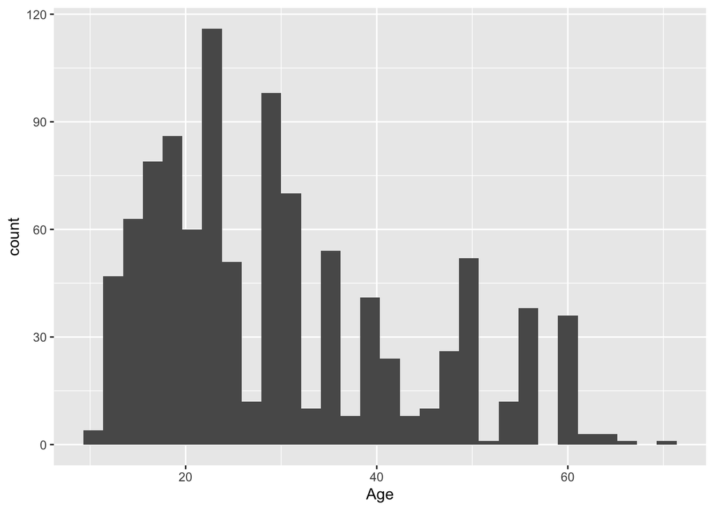

```r
histogram("Age")
```

### SystolicBP

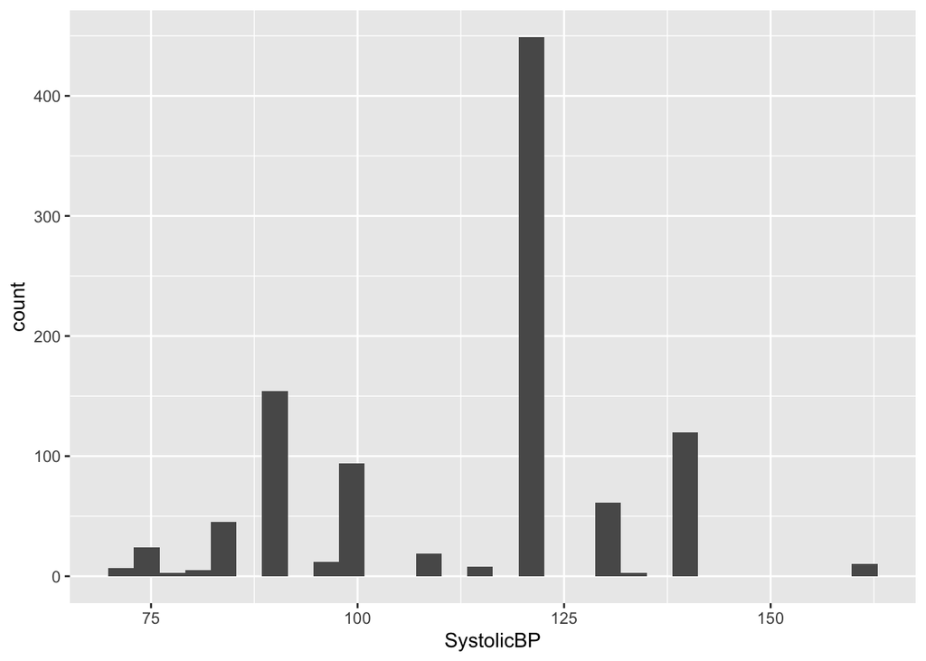

```r
histogram("SystolicBP")
```

Small number of entries with SystolicBP above 150. What are their risk levels?

```r
maternal_risk %>%
  filter(SystolicBP > 150)
```

```
## # A tibble: 10 × 7
##      Age SystolicBP DiastolicBP    BS BodyTemp HeartRate RiskLevel
##    <dbl>      <dbl>       <dbl> <dbl>    <dbl>     <dbl> <chr>
##  1    40        160         100    19       98        77 high risk
##  2    40        160         100    19       98        77 high risk
##  3    40        160         100    19       98        77 high risk
##  4    40        160         100    19       98        77 high risk
##  5    40        160         100    19       98        77 high risk
##  6    40        160         100    19       98        77 high risk
##  7    40        160         100    19       98        77 high risk
##  8    40        160         100    19       98        77 high risk
##  9    40        160         100    19       98        77 high risk
## 10    40        160         100    19       98        77 high risk
```

All ten rows are identical and classify each as high risk, which is expected given that these entries are outliers.

### DiastolicBP

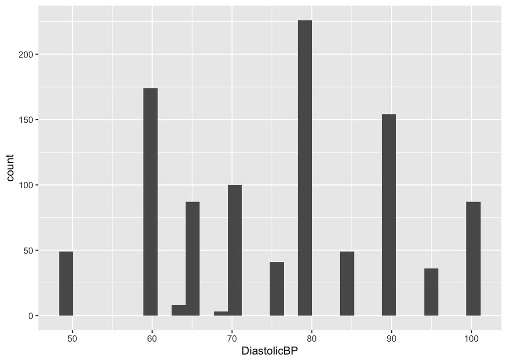

```r
histogram("DiastolicBP")
```

Fairly evenly distributed. Check under 50 group.

```r
maternal_risk %>%
  filter(DiastolicBP < 50)
```

```
## # A tibble: 25 × 7
##      Age SystolicBP DiastolicBP    BS BodyTemp HeartRate RiskLevel
##    <dbl>      <dbl>       <dbl> <dbl>    <dbl>     <dbl> <chr>
##  1    15         76          49   7.5       98        77 low risk
##  2    15         76          49   6.4       98        77 low risk
##  3    15         76          49   7.5       98        77 low risk
##  4    15         76          49   6.4       98        77 low risk
##  5    15         75          49   7.7       98        77 low risk
##  6    15         76          49   7.8       98        77 low risk
##  7    15         76          49   6.8       98        77 low risk
##  8    15         76          49   6.8       98        77 low risk
##  9    15         76          49   7.9       98        77 low risk
## 10    15         76          49   7.9       98        77 low risk
## # … with 15 more rows
```

25 entries with Diastolic blood pressure less than 50 (all 49). All are classified as low risk, so upon initial exploration, these low DiastolicBP outliers don’t seem to increase risk level.

### Blood Sugar

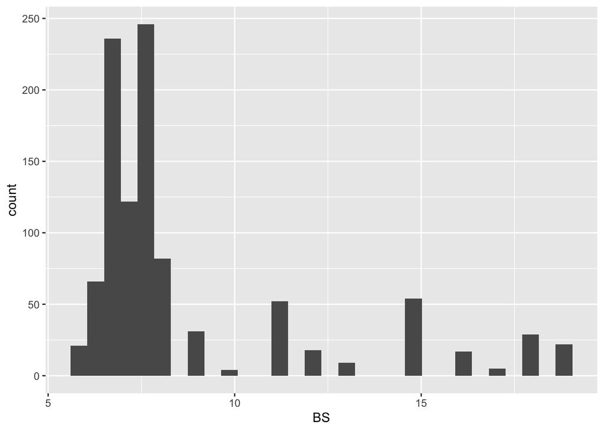

```r
histogram("BS")
```

The majority are under 10, but there are many entries spread between 10 and 20. Do these have higher risk level?

```r
maternal_risk %>%
  filter(BS > 10) %>%
  group_by(RiskLevel) %>%
  summarise(count = n())
```

```
## # A tibble: 3 × 2
##   RiskLevel count
##   <chr>     <int>
## 1 high risk   170
## 2 low risk      4
## 3 mid risk     32
```

### Body Temperature

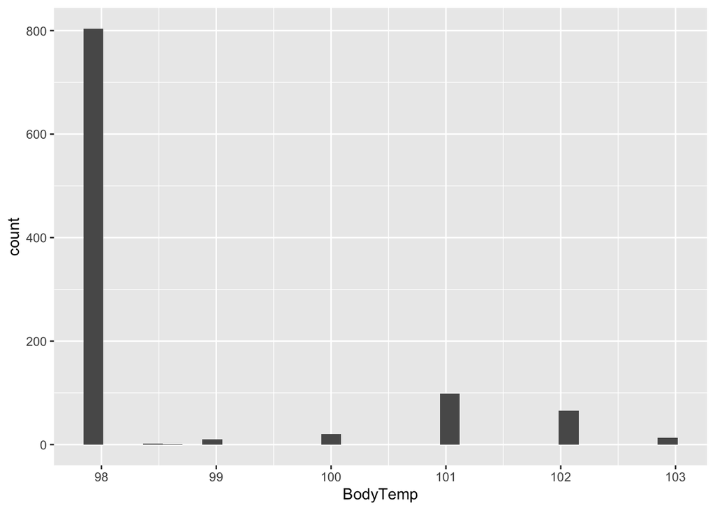

```r
histogram("BodyTemp")
```

The majority are in the normal temperature range (~98-99).

```r
maternal_risk %>%
  filter(BodyTemp > 100) %>%
  group_by(RiskLevel) %>%
  summarise(count = n())
```

```
## # A tibble: 3 × 2
##   RiskLevel count
##   <chr>     <int>
## 1 high risk    65
## 2 low risk     37
## 3 mid risk     75
```

There doesn’t seem to be a super strong correlation, but there are more mid to high risk entries than low risk in the group of higher body temperatures.

### HeartRate

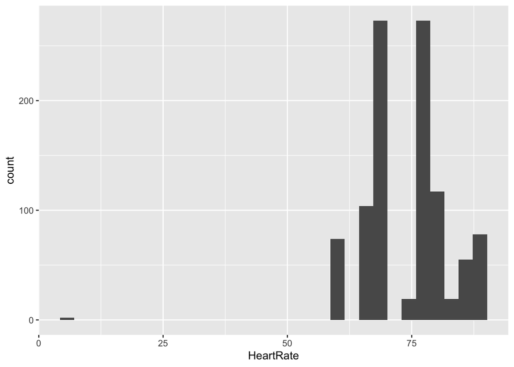

```r
histogram("HeartRate")
```

There is a major outlier, with heart rate less than 10.

```r
maternal_risk %>%
  filter(HeartRate < 25)
```

```
## # A tibble: 2 × 7
##     Age SystolicBP DiastolicBP    BS BodyTemp HeartRate RiskLevel
##   <dbl>      <dbl>       <dbl> <dbl>    <dbl>     <dbl> <chr>
## 1    16        120          75   7.9       98         7 low risk
## 2    16        120          75   7.9       98         7 low risk
```

HeartRate may have been entered incorrectly? This person is classified as low risk but has a heart rate of just 7, while the majority of heart rates in this dataset are around 70 bpm.

### Risk Level

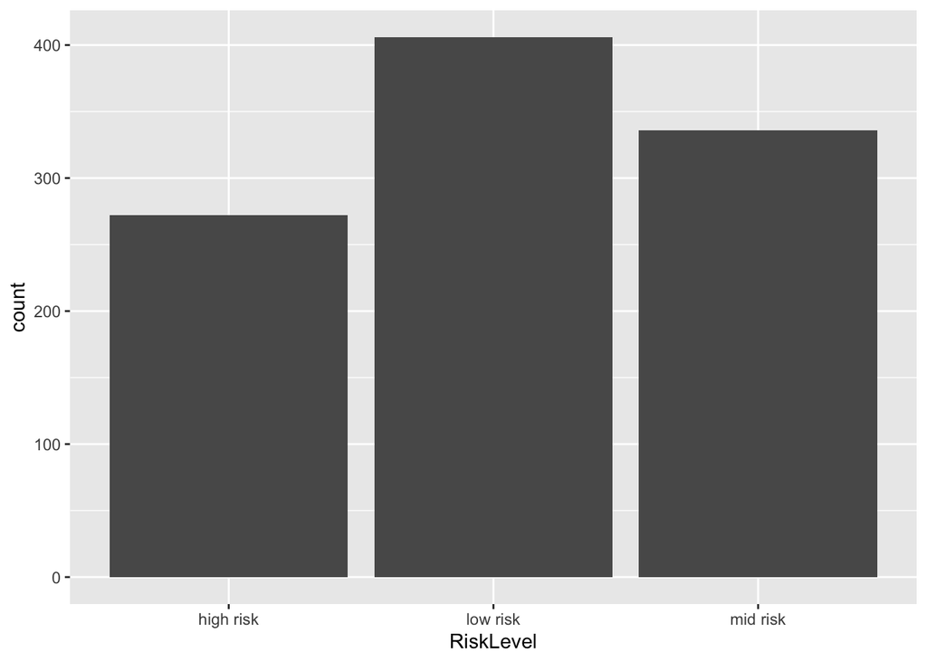

```r
# Plot discrete histogram (RiskLevel)
maternal_risk %>%
  ggplot() +
  geom_histogram(aes(x = RiskLevel), stat = "count")
```

Risk level mainly low but fairly evenly dispersed.

```r
maternal_risk %>%
  count(RiskLevel)
```

```
## # A tibble: 3 × 2
##   RiskLevel     n
##   <chr>     <int>
## 1 high risk   272
## 2 low risk    406
## 3 mid risk    336
```

The order of the levels isn’t intuitive - modify this in next step.

## Prepare processed data

RiskLevel in order that doesn’t make sense for plotting. Update factor to have levels increase from low to high.

```r
risks <- (c("low risk", "mid risk", "high risk"))

maternal_risk2 <- maternal_risk %>%
  mutate(RiskLevel = factor(RiskLevel, levels = risks))
```

# Global Mortality

## Check for potential data quality issues

```r
global <- read_csv("global_mortality.csv")
# no missing values in data we care about
sum(global %>%
      select(c(`Neonatal deaths (%)`, `Maternal deaths (%)`)) %>%
      is.na())
```

```
## [1] 0
```

Key Variables: - Maternal deaths (%): Percentage of all deaths in a given country & year where the cause was linked to maternal/childbirth complications - Neonatal deaths (%): Percentage of all deaths in a given country & year where death occurred within the first 28 days of life

```r
summary(global[c(1, 10, 25)])
```

```
##    country          Neonatal deaths (%) Maternal deaths (%)
##  Length:6156        Min.   : 0.04071    Min.   :0.00188
##  Class :character   1st Qu.: 0.68559    1st Qu.:0.03230
##  Mode  :character   Median : 3.89183    Median :0.23696
##                     Mean   : 4.56666    Mean   :0.58591
##                     3rd Qu.: 7.74003    3rd Qu.:1.00166
##                     Max.   :17.80683    Max.   :3.41435
```

### Check for duplicate entries

```r
# same size as original dataset, no duplicates
nrow(global %>% distinct())
```

```
## [1] 6156
```

```r
length(global %>% distinct())
```

```
## [1] 35
```

## Prepare processed data

```r
# keep most recent year
global <- global %>%
  filter(year == 2016)
```

## Build intuition about individual variables

```r
global <- read_csv("global_mortality.csv")
```

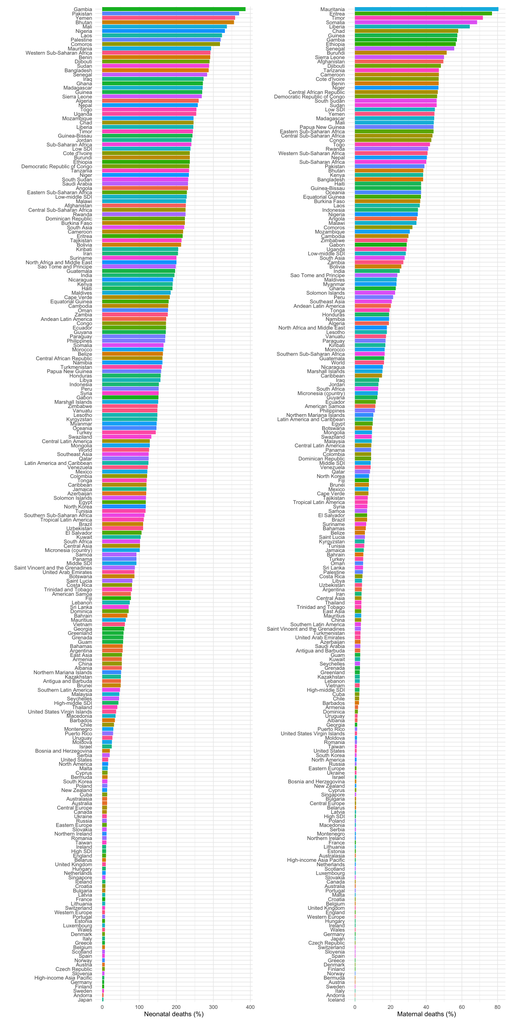

```r
countries1 <- ggplot(global) +
  geom_col(aes(`Neonatal deaths (%)`, reorder(country, `Neonatal deaths (%)`), fill = country)) +
  ylab(label = "") +
  theme(axis.text = element_text(size = 2)) +
  theme_minimal() +
  guides(fill="none")

countries2 <- ggplot(global) +
  geom_col(aes(`Maternal deaths (%)`, reorder(country, `Maternal deaths (%)`), fill = country)) +
  ylab(label = "") +
  theme(axis.text = element_text(size = 2)) +
  theme_minimal() +
  guides(fill="none")

countries1 + countries2
```

# Interventions & Maternal Outcomes

## Check for potential data quality issues

The following .csv files were hand-generated from the cited paper (more details in the write-up).

```r
interventions <- read_csv("interventions.csv")
outcomes <- read_csv("maternal_outcomes.csv")
# no missing values
sum(interventions %>%
      is.na())
```

```
## [1] 0
```

```r
sum(outcomes %>%
      is.na())
```

```
## [1] 0
```

“interventions” Variables:

Number of pregnant people who had…

- external_tocomoter: external electronic fetal monitoring
- fetal_scalp_electrode: internal electronic fetal monitoring
- amniotomy: purposeful puncturing of the amniotic sac
- oxytocin: drug used to induce labor, brand name Pitocin
- nitrous_oxide: “laughing gas”
- epidural: numbing prodeduce for the lower part of the body
- narcotic: pain-relieving drugs
- spontaneous_vaginal: vaginal birth without forceps or other mechanical interventions
- assisted_vaginal: vaginal birth with mechanical assistance
- cesarean: birth via cesarean-section surgery
- episiotomy: cutting of the perineum for vaginal birth

total: total number in each birth setting/caregiver (same as below)

“outcomes” variables:

Number of pregnant people who experienced…

- prolapsed_cord: a prolapsed umbilical cord
- uterine_rupture: a ruputure of the uterus
- postpartum_hemorrhage: hemorrhaging after giving birth
- blood_transfusion: requiring a blood transfusion
- obstetric_shock: shock, usually caused by excessive blood loss
- death
- placenta_removal: manual removal of the placenta (rather than natural expulsion)
- uterine_prolapse: a prolapsed uterus
- pyrexia: fever
- uti: urinary tract infection
- puerpural_fever: prolonged fever immediately after giving birth
- wound_infection: infection at the site of a wound
- no_tear: no tearing from birth
- first_second_degree: first or second degree tears
- third_fourth_degree: third or fourth degree tears
- unknown_degree: tearing of unknown degree
- cervical_tear: tearing of the cervix

total: total number in each birth setting/caregiver (same as above)

```r
summary(interventions)
```

```
##    setting           caregiver         external_tocometer fetal_scalp_electrode
##  Length:3           Length:3           Min.   : 389       Min.   : 60.0
##  Class :character   Class :character   1st Qu.:1180       1st Qu.:153.5
##  Mode  :character   Mode  :character   Median :1970       Median :247.0
##                                        Mean   :2174       Mean   :285.0
##                                        3rd Qu.:3067       3rd Qu.:397.5
##                                        Max.   :4164       Max.   :548.0
##    amniotomy       oxytocin     nitrous_oxide     epidural
##  Min.   : 560   Min.   :172.0   Min.   : 199   Min.   : 224.0
##  1st Qu.:1039   1st Qu.:387.5   1st Qu.: 882   1st Qu.: 562.5
##  Median :1518   Median :603.0   Median :1565   Median : 901.0
##  Mean   :1397   Mean   :585.3   Mean   :1550   Mean   : 870.7
##  3rd Qu.:1815   3rd Qu.:792.0   3rd Qu.:2226   3rd Qu.:1194.0
##  Max.   :2112   Max.   :981.0   Max.   :2887   Max.   :1487.0
##     narcotic      spontaneous_vaginal assisted_vaginal    cesarean
##  Min.   : 122.0   Min.   :2605        Min.   : 86.0    Min.   :208.0
##  1st Qu.: 417.5   1st Qu.:3258        1st Qu.:215.0    1st Qu.:353.0
##  Median : 713.0   Median :3910        Median :344.0    Median :498.0
##  Mean   : 904.0   Mean   :3507        Mean   :388.7    Mean   :431.3
##  3rd Qu.:1295.0   3rd Qu.:3958        3rd Qu.:540.0    3rd Qu.:543.0
##  Max.   :1877.0   Max.   :4007        Max.   :736.0    Max.   :588.0
##    episiotomy        total
##  Min.   : 84.0   Min.   :2899
##  1st Qu.:186.5   1st Qu.:3826
##  Median :289.0   Median :4752
##  Mean   :391.0   Mean   :4327
##  3rd Qu.:544.5   3rd Qu.:5042
##  Max.   :800.0   Max.   :5331
```

```r
summary(outcomes)
```

```
##    setting           caregiver         prolapsed_cord  uterine_rupture
##  Length:3           Length:3           Min.   :2.000   Min.   :0.0000
##  Class :character   Class :character   1st Qu.:4.000   1st Qu.:0.0000
##  Mode  :character   Mode  :character   Median :6.000   Median :0.0000
##                                        Mean   :5.667   Mean   :0.6667
##                                        3rd Qu.:7.500   3rd Qu.:1.0000
##                                        Max.   :9.000   Max.   :2.0000
##  postpartum_hemorrhage blood_transfusion obstetric_shock     death
##  Min.   :110.0         Min.   : 2.0      Min.   :1       Min.   :0
##  1st Qu.:197.5         1st Qu.: 6.0      1st Qu.:1       1st Qu.:0
##  Median :285.0         Median :10.0      Median :1       Median :0
##  Mean   :250.7         Mean   : 9.0      Mean   :1       Mean   :0
##  3rd Qu.:321.0         3rd Qu.:12.5      3rd Qu.:1       3rd Qu.:0
##  Max.   :357.0         Max.   :15.0      Max.   :1       Max.   :0
##  placenta_removal uterine_prolapse    pyrexia            uti
##  Min.   :28.00    Min.   :1.000    Min.   : 19.00   Min.   :0.0
##  1st Qu.:56.50    1st Qu.:1.000    1st Qu.: 43.50   1st Qu.:0.5
##  Median :85.00    Median :1.000    Median : 68.00   Median :1.0
##  Mean   :67.67    Mean   :1.333    Mean   : 80.33   Mean   :2.0
##  3rd Qu.:87.50    3rd Qu.:1.500    3rd Qu.:111.00   3rd Qu.:3.0
##  Max.   :90.00    Max.   :2.000    Max.   :154.00   Max.   :5.0
##  puerpural_fever wound_infection    no_tear     first_second_degree
##  Min.   :1.0     Min.   : 0.0    Min.   :1578   Min.   :1262
##  1st Qu.:2.5     1st Qu.: 5.5    1st Qu.:1884   1st Qu.:1824
##  Median :4.0     Median :11.0    Median :2189   Median :2387
##  Mean   :4.0     Mean   : 9.0    Mean   :2019   Mean   :2162
##  3rd Qu.:5.5     3rd Qu.:13.5    3rd Qu.:2240   3rd Qu.:2612
##  Max.   :7.0     Max.   :16.0    Max.   :2291   Max.   :2836
##  third_fourth_degree unknown_degree  cervical_tear       total
##  Min.   : 34.0       Min.   :21.00   Min.   :2.000   Min.   :2899
##  1st Qu.: 85.5       1st Qu.:23.00   1st Qu.:3.000   1st Qu.:3826
##  Median :137.0       Median :25.00   Median :4.000   Median :4752
##  Mean   :118.0       Mean   :28.33   Mean   :3.667   Mean   :4327
##  3rd Qu.:160.0       3rd Qu.:32.00   3rd Qu.:4.500   3rd Qu.:5042
##  Max.   :183.0       Max.   :39.00   Max.   :5.000   Max.   :5331
```

Some variables have a very low sample size/count, which is not as useful for visualization.

### Check for duplicate entries

As these two .csv’s were made by hand (and are very small overall), we verify there are no duplicate entries.

## Prepare processed data

```r
interventions_ratios <- interventions %>%
  mutate_at(vars(-c(setting, caregiver, total)), funs(./total)) %>%
  unite("birth_plan", c(setting, caregiver), sep = ", ")
outcomes_ratios <- outcomes %>%
  mutate_at(vars(-c(setting, caregiver, total)), funs(./total)) %>%
  unite("birth_plan", c(setting, caregiver), sep = ", ")
```

## Build intuition about individual variables

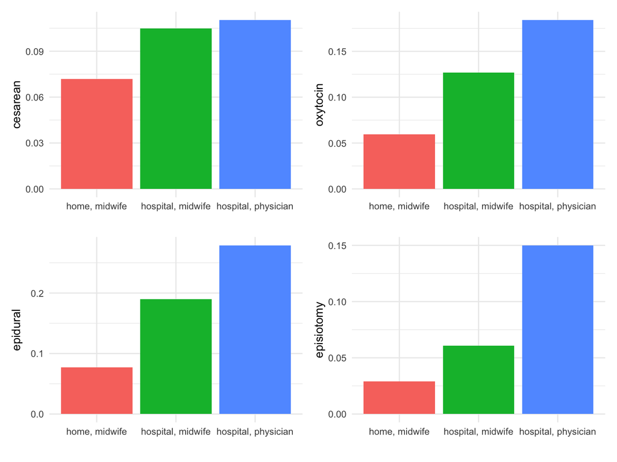

```r
i1 <- ggplot(interventions_ratios) +
  geom_col(aes(birth_plan, cesarean, fill = birth_plan)) +
  theme(axis.text = element_text(size = 1)) +
  theme_minimal() +
  guides(fill="none") +
  xlab("")

i2 <- ggplot(interventions_ratios) +
  geom_col(aes(birth_plan, oxytocin, fill = birth_plan)) +
  theme(axis.text = element_text(size = 1)) +
  theme_minimal() +
  guides(fill="none") +
  xlab("")

i3 <- ggplot(interventions_ratios) +
  geom_col(aes(birth_plan, epidural, fill = birth_plan)) +
  theme(axis.text = element_text(size = 1)) +
  theme_minimal() +
  guides(fill="none") +
  xlab("")

i4 <- ggplot(interventions_ratios) +
  geom_col(aes(birth_plan, episiotomy, fill = birth_plan)) +
  theme(axis.text = element_text(size = 1)) +
  theme_minimal() +
  guides(fill="none") +
  xlab("")

(i1 + i2) / (i3 + i4)
```